# Project: TMDB Movie Data Analysis

- Introduction
- Data Wrangling
- Exploratory Data Analysis
- Conclusions

## Introduction

### Dataset Description

This data set contains information about 10,000 movies collected from The Movie Database (TMDb), including user ratings and revenue.

### Question(s) for Analysis

1.Which genres are most popular from year to year?

2.What kinds of properties are associated with movies that have high revenues?

```python
# loading libraries
import numpy as np
import pandas as pd
import matplotlib.pyplot as plt
import seaborn as sns
%matplotlib inline
```

## Data Wrangling

### General Properties

```python
# loading datafile
df = pd.read_csv('tmdb-movies.csv')
df.head()
```

|  | id | imdb_id | popularity | budget | revenue | original_title | cast | homepage | director | tagline | ... | overview | runtime | genres | production_companies | release_date | vote_count | vote_average | release_year | budget_adj | revenue_adj |
| --- | --- | --- | --- | --- | --- | --- | --- | --- | --- | --- | --- | --- | --- | --- | --- | --- | --- | --- | --- | --- | --- |
| 0 | 135397 | tt0369610 | 32.985763 | 150000000 | 1513528810 | Jurassic World | Chris Pratt\|Bryce Dallas Howard\|Irrfan Khan\|Vi... | http://www.jurassicworld.com/ | Colin Trevorrow | The park is open. | ... | Twenty-two years after the events of Jurassic ... | 124 | Action\|Adventure\|Science Fiction\|Thriller | Universal Studios\|Amblin Entertainment\|Legenda... | 6/9/15 | 5562 | 6.5 | 2015 | 1.379999e+08 | 1.392446e+09 |
| 1 | 76341 | tt1392190 | 28.419936 | 150000000 | 378436354 | Mad Max: Fury Road | Tom Hardy\|Charlize Theron\|Hugh Keays-Byrne\|Nic... | http://www.madmaxmovie.com/ | George Miller | What a Lovely Day. | ... | An apocalyptic story set in the furthest reach... | 120 | Action\|Adventure\|Science Fiction\|Thriller | Village Roadshow Pictures\|Kennedy Miller Produ... | 5/13/15 | 6185 | 7.1 | 2015 | 1.379999e+08 | 3.481613e+08 |
| 2 | 262500 | tt2908446 | 13.112507 | 110000000 | 295238201 | Insurgent | Shailene Woodley\|Theo James\|Kate Winslet\|Ansel... | http://www.thedivergentseries.movie/#insurgent | Robert Schwentke | One Choice Can Destroy You | ... | Beatrice Prior must confront her inner demons ... | 119 | Adventure\|Science Fiction\|Thriller | Summit Entertainment\|Mandeville Films\|Red Wago... | 3/18/15 | 2480 | 6.3 | 2015 | 1.012000e+08 | 2.716190e+08 |
| 3 | 140607 | tt2488496 | 11.173104 | 200000000 | 2068178225 | Star Wars: The Force Awakens | Harrison Ford\|Mark Hamill\|Carrie Fisher\|Adam D... | http://www.starwars.com/films/star-wars-episod... | J.J. Abrams | Every generation has a story. | ... | Thirty years after defeating the Galactic Empi... | 136 | Action\|Adventure\|Science Fiction\|Fantasy | Lucasfilm\|Truenorth Productions\|Bad Robot | 12/15/15 | 5292 | 7.5 | 2015 | 1.839999e+08 | 1.902723e+09 |
| 4 | 168259 | tt2820852 | 9.335014 | 190000000 | 1506249360 | Furious 7 | Vin Diesel\|Paul Walker\|Jason Statham\|Michelle ... | http://www.furious7.com/ | James Wan | Vengeance Hits Home | ... | Deckard Shaw seeks revenge against Dominic Tor... | 137 | Action\|Crime\|Thriller | Universal Pictures\|Original Film\|Media Rights ... | 4/1/15 | 2947 | 7.3 | 2015 | 1.747999e+08 | 1.385749e+09 |

5 rows × 21 columns

```python
# rows and columns of dataframe
df.shape
```

```
(10866, 21)
```

```python
# The dataframe has one duplicated row
sum(df.duplicated())
```

```
1
```

```python
# data types of column values
df.dtypes
```

```
id                        int64
imdb_id                  object
popularity              float64
budget                    int64
revenue                   int64
original_title           object
cast                     object
homepage                 object
director                 object
tagline                  object
keywords                 object
overview                 object
runtime                   int64
genres                   object
production_companies     object
release_date             object
vote_count                int64
vote_average            float64
release_year              int64
budget_adj              float64
revenue_adj             float64
dtype: object
```

```python
# dataframe info
df.info()
```

```
<class 'pandas.core.frame.DataFrame'>
RangeIndex: 10866 entries, 0 to 10865
Data columns (total 21 columns):
 #   Column                Non-Null Count  Dtype
---  ------                --------------  -----
 0   id                    10866 non-null  int64
 1   imdb_id               10856 non-null  object
 2   popularity            10866 non-null  float64
 3   budget                10866 non-null  int64
 4   revenue               10866 non-null  int64
 5   original_title        10866 non-null  object
 6   cast                  10790 non-null  object
 7   homepage              2936 non-null   object
 8   director              10822 non-null  object
 9   tagline               8042 non-null   object
 10  keywords              9373 non-null   object
 11  overview              10862 non-null  object
 12  runtime               10866 non-null  int64
 13  genres                10843 non-null  object
 14  production_companies  9836 non-null   object
 15  release_date          10866 non-null  object
 16  vote_count            10866 non-null  int64
 17  vote_average          10866 non-null  float64
 18  release_year          10866 non-null  int64
 19  budget_adj            10866 non-null  float64
 20  revenue_adj           10866 non-null  float64
dtypes: float64(4), int64(6), object(11)
memory usage: 1.7+ MB
```

```python
# checking for unique values for better knowing the data
df.nunique()
```

```
id                      10865
imdb_id                 10855
popularity              10814
budget                    557
revenue                  4702
original_title          10571
cast                    10719
homepage                 2896
director                 5067
tagline                  7997
keywords                 8804
overview                10847
runtime                   247
genres                   2039
production_companies     7445
release_date             5909
vote_count               1289
vote_average               72
release_year               56
budget_adj               2614
revenue_adj              4840
dtype: int64
```

```python
# checking for null values
df.isnull().sum()
```

```
id                         0
imdb_id                   10
popularity                 0
budget                     0
revenue                    0
original_title             0
cast                      76
homepage                7930
director                  44
tagline                 2824
keywords                1493
overview                   4
runtime                    0
genres                    23
production_companies    1030
release_date               0
vote_count                 0
vote_average               0
release_year               0
budget_adj                 0
revenue_adj                0
dtype: int64
```

### Data Cleaning

```python
# removing the duplicated row
df.drop_duplicates(inplace = True)
sum(df.duplicated())
```

```
0
```

```python
# removing unuseful columns for our analysis
df.drop(['id', 'cast', 'homepage', 'tagline','overview', 'keywords','budget', 'revenue', 'release_date', 'imdb_id'], axis = 1, inplace = True)
```

```python
# first 5 rows of dataframe
df.head()
```

|  | popularity | original_title | director | runtime | genres | production_companies | vote_count | vote_average | release_year | budget_adj | revenue_adj |
| --- | --- | --- | --- | --- | --- | --- | --- | --- | --- | --- | --- |
| 0 | 32.985763 | Jurassic World | Colin Trevorrow | 124 | Action\|Adventure\|Science Fiction\|Thriller | Universal Studios\|Amblin Entertainment\|Legenda... | 5562 | 6.5 | 2015 | 1.379999e+08 | 1.392446e+09 |
| 1 | 28.419936 | Mad Max: Fury Road | George Miller | 120 | Action\|Adventure\|Science Fiction\|Thriller | Village Roadshow Pictures\|Kennedy Miller Produ... | 6185 | 7.1 | 2015 | 1.379999e+08 | 3.481613e+08 |
| 2 | 13.112507 | Insurgent | Robert Schwentke | 119 | Adventure\|Science Fiction\|Thriller | Summit Entertainment\|Mandeville Films\|Red Wago... | 2480 | 6.3 | 2015 | 1.012000e+08 | 2.716190e+08 |
| 3 | 11.173104 | Star Wars: The Force Awakens | J.J. Abrams | 136 | Action\|Adventure\|Science Fiction\|Fantasy | Lucasfilm\|Truenorth Productions\|Bad Robot | 5292 | 7.5 | 2015 | 1.839999e+08 | 1.902723e+09 |
| 4 | 9.335014 | Furious 7 | James Wan | 137 | Action\|Crime\|Thriller | Universal Pictures\|Original Film\|Media Rights ... | 2947 | 7.3 | 2015 | 1.747999e+08 | 1.385749e+09 |

```python
df.shape
```

```
(10865, 11)
```

```python
# identifying null values in each column but we will neglect the null values in selected columns
df.isnull().sum()
```

```
popularity                 0
original_title             0
director                  44
runtime                    0
genres                    23
production_companies    1030
vote_count                 0
vote_average               0
release_year               0
budget_adj                 0
revenue_adj                0
dtype: int64
```

```python
# Saving edited dataframe after some implmentation as checkpoint
df.to_csv('df_v1.csv', index = False)
```

Expanding genres column for answering first question then adding it to the dataframe

```python
df_genres = df['genres'].str.split('|', expand=True)
```

```python
df_genres
```

|  | 0 | 1 | 2 | 3 | 4 |
| --- | --- | --- | --- | --- | --- |
| 0 | Action | Adventure | Science Fiction | Thriller | None |
| 1 | Action | Adventure | Science Fiction | Thriller | None |
| 2 | Adventure | Science Fiction | Thriller | None | None |
| 3 | Action | Adventure | Science Fiction | Fantasy | None |
| 4 | Action | Crime | Thriller | None | None |
| ... | ... | ... | ... | ... | ... |
| 10861 | Documentary | None | None | None | None |
| 10862 | Action | Adventure | Drama | None | None |
| 10863 | Mystery | Comedy | None | None | None |
| 10864 | Action | Comedy | None | None | None |
| 10865 | Horror | None | None | None | None |

10865 rows × 5 columns

```python
genres_out = df_genres.stack().droplevel(1).rename('genres')
```

```python
genres_out
```

```
0                 Action
0              Adventure
0        Science Fiction
0               Thriller
1                 Action
              ...
10863            Mystery
10863             Comedy
10864             Action
10864             Comedy
10865             Horror
Name: genres, Length: 26955, dtype: object
```

```python
df.drop(['genres'], axis = 1, inplace = True)
```

```python
df = pd.merge(df, genres_out, left_index=True, right_index=True)
df
```

|  | popularity | original_title | director | runtime | production_companies | vote_count | vote_average | release_year | budget_adj | revenue_adj | genres |
| --- | --- | --- | --- | --- | --- | --- | --- | --- | --- | --- | --- |
| 0 | 32.985763 | Jurassic World | Colin Trevorrow | 124 | Universal Studios\|Amblin Entertainment\|Legenda... | 5562 | 6.5 | 2015 | 1.379999e+08 | 1.392446e+09 | Action |
| 0 | 32.985763 | Jurassic World | Colin Trevorrow | 124 | Universal Studios\|Amblin Entertainment\|Legenda... | 5562 | 6.5 | 2015 | 1.379999e+08 | 1.392446e+09 | Adventure |
| 0 | 32.985763 | Jurassic World | Colin Trevorrow | 124 | Universal Studios\|Amblin Entertainment\|Legenda... | 5562 | 6.5 | 2015 | 1.379999e+08 | 1.392446e+09 | Science Fiction |
| 0 | 32.985763 | Jurassic World | Colin Trevorrow | 124 | Universal Studios\|Amblin Entertainment\|Legenda... | 5562 | 6.5 | 2015 | 1.379999e+08 | 1.392446e+09 | Thriller |
| 1 | 28.419936 | Mad Max: Fury Road | George Miller | 120 | Village Roadshow Pictures\|Kennedy Miller Produ... | 6185 | 7.1 | 2015 | 1.379999e+08 | 3.481613e+08 | Action |
| ... | ... | ... | ... | ... | ... | ... | ... | ... | ... | ... | ... |
| 10863 | 0.065141 | Beregis Avtomobilya | Eldar Ryazanov | 94 | Mosfilm | 11 | 6.5 | 1966 | 0.000000e+00 | 0.000000e+00 | Mystery |
| 10863 | 0.065141 | Beregis Avtomobilya | Eldar Ryazanov | 94 | Mosfilm | 11 | 6.5 | 1966 | 0.000000e+00 | 0.000000e+00 | Comedy |
| 10864 | 0.064317 | What's Up, Tiger Lily? | Woody Allen | 80 | Benedict Pictures Corp. | 22 | 5.4 | 1966 | 0.000000e+00 | 0.000000e+00 | Action |
| 10864 | 0.064317 | What's Up, Tiger Lily? | Woody Allen | 80 | Benedict Pictures Corp. | 22 | 5.4 | 1966 | 0.000000e+00 | 0.000000e+00 | Comedy |
| 10865 | 0.035919 | Manos: The Hands of Fate | Harold P. Warren | 74 | Norm-Iris | 15 | 1.5 | 1966 | 1.276423e+05 | 0.000000e+00 | Horror |

26955 rows × 11 columns

```python
# saving dataframe thats ready for genres analysis after implmentation
df.to_csv('df_genres.csv', index = False)
```

## Exploratory Data Analysis

### Which genres are most popular from year to year?

```python
# load genres dataframe that was created in previous section
df = pd.read_csv('df_genres.csv')
df.head()
```

|  | popularity | original_title | director | runtime | production_companies | vote_count | vote_average | release_year | budget_adj | revenue_adj | genres |
| --- | --- | --- | --- | --- | --- | --- | --- | --- | --- | --- | --- |
| 0 | 32.985763 | Jurassic World | Colin Trevorrow | 124 | Universal Studios\|Amblin Entertainment\|Legenda... | 5562 | 6.5 | 2015 | 1.379999e+08 | 1.392446e+09 | Action |
| 1 | 32.985763 | Jurassic World | Colin Trevorrow | 124 | Universal Studios\|Amblin Entertainment\|Legenda... | 5562 | 6.5 | 2015 | 1.379999e+08 | 1.392446e+09 | Adventure |
| 2 | 32.985763 | Jurassic World | Colin Trevorrow | 124 | Universal Studios\|Amblin Entertainment\|Legenda... | 5562 | 6.5 | 2015 | 1.379999e+08 | 1.392446e+09 | Science Fiction |
| 3 | 32.985763 | Jurassic World | Colin Trevorrow | 124 | Universal Studios\|Amblin Entertainment\|Legenda... | 5562 | 6.5 | 2015 | 1.379999e+08 | 1.392446e+09 | Thriller |
| 4 | 28.419936 | Mad Max: Fury Road | George Miller | 120 | Village Roadshow Pictures\|Kennedy Miller Produ... | 6185 | 7.1 | 2015 | 1.379999e+08 | 3.481613e+08 | Action |

```python
# filter dataframe with release year and genres to popularity mean and sorting them
df_filtered = df.groupby(['release_year', 'genres'], as_index = False)['popularity'].mean()
df_filtered = df_filtered.sort_values(['release_year', 'popularity'], ascending = [False, False]).reset_index(drop=True)
df_filtered.iloc[0]
```

```
release_year         2015
genres          Adventure
popularity       3.283786
Name: 0, dtype: object
```

```python
# filtering the highest means of popularity for each release year and genres in new dataframe for drwaing conclution
df_filtered_2 = pd.DataFrame()
for i in list(range(1960,2016)):
    a = df_filtered.query(f'release_year == {i}').head(1)
    df_filtered_2 = pd.concat([df_filtered_2, a], axis=0).reset_index(drop=True)
df_filtered_2.head()
```

|  | release_year | genres | popularity |
| --- | --- | --- | --- |
| 0 | 1960 | Thriller | 0.811910 |
| 1 | 1961 | Animation | 2.631987 |
| 2 | 1962 | Adventure | 0.942513 |
| 3 | 1963 | Animation | 2.180410 |
| 4 | 1964 | War | 0.930959 |

```python
# saving the last genres dataframe that will be used for drawing conclution of first question
df_filtered_2.to_csv('df_genres_v1.csv', index = False)
```

### What kinds of properties are associated with movies that have high revenues?

```python
# load genres dataframe
df = pd.read_csv('df_genres.csv')
df.head()
```

|  | popularity | original_title | director | runtime | production_companies | vote_count | vote_average | release_year | budget_adj | revenue_adj | genres |
| --- | --- | --- | --- | --- | --- | --- | --- | --- | --- | --- | --- |
| 0 | 32.985763 | Jurassic World | Colin Trevorrow | 124 | Universal Studios\|Amblin Entertainment\|Legenda... | 5562 | 6.5 | 2015 | 1.379999e+08 | 1.392446e+09 | Action |
| 1 | 32.985763 | Jurassic World | Colin Trevorrow | 124 | Universal Studios\|Amblin Entertainment\|Legenda... | 5562 | 6.5 | 2015 | 1.379999e+08 | 1.392446e+09 | Adventure |
| 2 | 32.985763 | Jurassic World | Colin Trevorrow | 124 | Universal Studios\|Amblin Entertainment\|Legenda... | 5562 | 6.5 | 2015 | 1.379999e+08 | 1.392446e+09 | Science Fiction |
| 3 | 32.985763 | Jurassic World | Colin Trevorrow | 124 | Universal Studios\|Amblin Entertainment\|Legenda... | 5562 | 6.5 | 2015 | 1.379999e+08 | 1.392446e+09 | Thriller |
| 4 | 28.419936 | Mad Max: Fury Road | George Miller | 120 | Village Roadshow Pictures\|Kennedy Miller Produ... | 6185 | 7.1 | 2015 | 1.379999e+08 | 3.481613e+08 | Action |

```python
df.shape
```

```
(26955, 11)
```

```python
# checking for zero values (we know from before it does not have any null values)
df['revenue_adj'].describe()
```

```
count    2.695500e+04
mean     6.088986e+07
std      1.615305e+08
min      0.000000e+00
25%      0.000000e+00
50%      0.000000e+00
75%      4.376460e+07
max      2.827124e+09
Name: revenue_adj, dtype: float64
```

```python
# checking the number of zero values in revenue
df['revenue_adj'].value_counts()
```

```
0.000000e+00    14291
8.990674e+07        8
8.103642e+07        7
1.000000e+06        6
2.093547e+08        6
                ...
8.572918e+07        1
1.006532e+08        1
2.593340e+07        1
3.289876e+07        1
2.678010e+06        1
Name: revenue_adj, Length: 4840, dtype: int64
```

```python
# checking the number of zero values in budget
df['budget_adj'].value_counts()
```

```
0.000000e+00    13354
2.103337e+07       42
2.000000e+07       41
2.032801e+07       39
1.016400e+07       37
                ...
8.312007e+06        1
6.118561e+07        1
4.617782e+05        1
1.339157e+08        1
1.276423e+05        1
Name: budget_adj, Length: 2613, dtype: int64
```

```python
# removing revenue zero values as they will affect our analysis accuracy
df = df[df.revenue_adj != 0]
```

```python
# saving the last dataframe that will be used for drawing conclution of our second question
df.to_csv('df_v2.csv', index = False)
```

```python
# Quick anlysis for the revenue to get numbers sense
df['revenue_adj'].describe()
```

```
count    1.266400e+04
mean     1.296025e+08
std      2.159459e+08
min      2.370705e+00
25%      1.323018e+07
50%      5.083352e+07
75%      1.526580e+08
max      2.827124e+09
Name: revenue_adj, dtype: float64
```

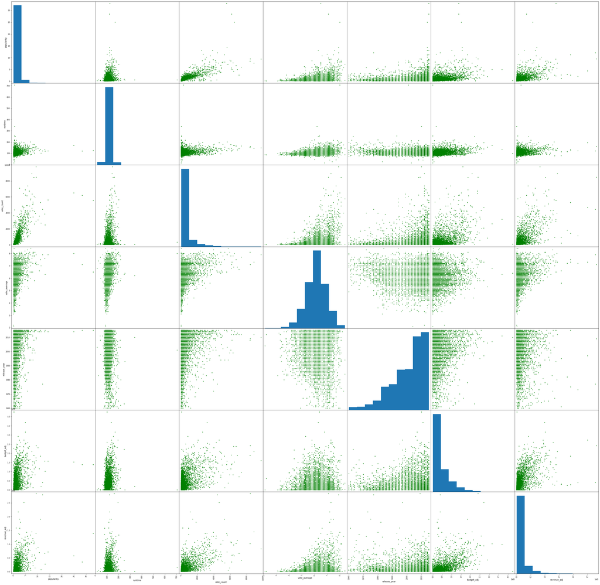

```python
# exploring for correlation relations around numeric value columns
pd.plotting.scatter_matrix(df, figsize = (50,50), color = 'green');
```

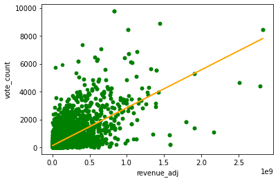

```python
# plotting scatter plot for revenue to value count for clearer analysis
def vote_to_revenue(df):
    df.plot(y='vote_count', x= 'revenue_adj', kind = 'scatter',color = 'green')
    y= df.vote_count
    x = df.revenue_adj
    m, b = np.polyfit(x, y, 1)
    plt.plot(x, m*x+b, color = 'orange')
vote_to_revenue(df)
```

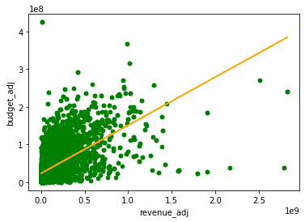

```python
# Removing zero values from budget then plotting scatter plot for revenue to budget for clearer analysis
def budget_to_revenue(df):
    df[df.budget_adj != 0].plot(y='budget_adj', x= 'revenue_adj', kind = 'scatter', color = 'green')
    y = df.budget_adj
    x = df.revenue_adj
    m, b = np.polyfit(x, y, 1)
    plt.plot(x, m*x+b, color = 'orange');
budget_to_revenue(df)
```

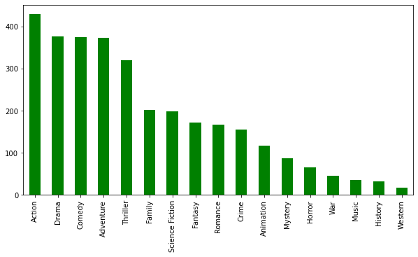

```python
# making new dataframe with the top 25% of movies revenue then counting movie genres for them
def top_genres_count(df):
    df_g = df.query('revenue_adj >= 1.526580e+08')
    df_g['genres'].value_counts().plot(kind = 'bar', color = 'green',figsize = (10,5));
top_genres_count(df)
```

```python
# checking out if there is an outlier directors so they have effect on our revenue factor analysis
def top_directors(df):
    df_g = df.query('revenue_adj >= 1.526580e+08')
    return df_g['director'].value_counts()
top_directors(df).describe()
```

```
count    517.000000
mean       6.123791
std        5.964702
min        1.000000
25%        3.000000
50%        4.000000
75%        7.000000
max       56.000000
Name: director, dtype: float64
```

## Conclusions

### Q1: Which genres are most popular from year to year?

#### Limitations:

#### There was some minimal limition because of missing values for genres but they were only 23 of 10866 values so that is okay.

```python
# load last genres data frame
df = pd.read_csv('df_genres_v1.csv')
```

plotting bar chart with years in ascending order and genres with popularity rate

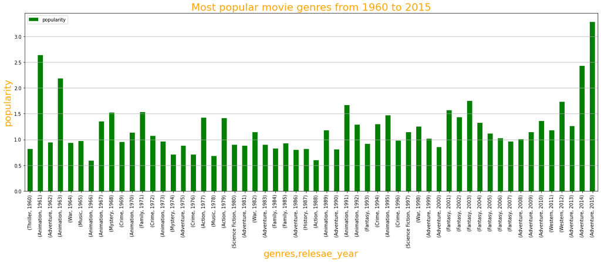

```python
df.set_index(['genres','release_year']).plot(kind = 'bar', figsize = (22,7), color= 'green')
plt.xlabel('genres,relesae_year', fontsize=20, color = 'orange')
plt.ylabel('popularity', fontsize = 20, color = 'orange')
plt.legend()
plt.title('Most popular movie genres from 1960 to 2015',fontsize = 22, color = 'orange')
plt.grid(axis = 'y');
```

summarizing the top count genres

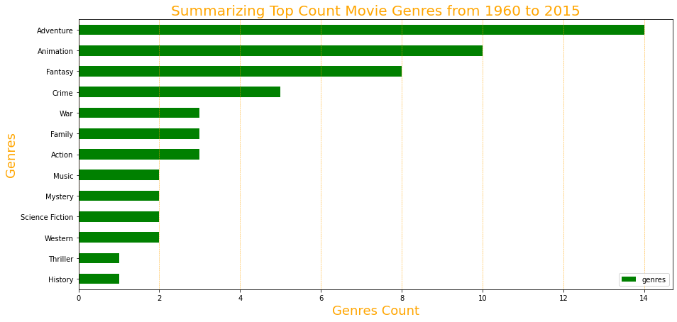

```python
df.genres.value_counts().plot(kind = 'barh', color = 'green', figsize = (15,7)).invert_yaxis()
plt.title('Summarizing Top Count Movie Genres from 1960 to 2015',fontsize = 20, color = 'orange')
plt.xlabel('Genres Count', fontsize=18, color = 'orange')
plt.ylabel('Genres', fontsize = 18, color = 'orange')
plt.legend()
plt.grid(axis = 'x', color = 'orange', linestyle = '--', linewidth = 0.5);
```

#### Conclusions:

#### From the previos visualization we see that over 56 years the top 3 popular genres were (Adventure, Animation, Fantasy), then the rest of genres came with minimal difference.

#### In the next section we will see if the genres with high popularity will also have high revenues or not.

### Q2: What kinds of properties are associated with movies that have high revenues?

#### Limitations:

#### Limitation in answering this question was in zero values of Revenue (53% of revenue data were zero values), and that was big precentage to take either mean or median to fill them as they will have a big misleading impact on our analysis, so we have removed them.

#### Also 49.5% of budget values are zero values that have been removed too but only at plotting the correlation so they will not affect our revenue analysis except in the direct relation between them.

```python
# load last edited dataframe
df = pd.read_csv('df_v2.csv')
```

Positive correlation betwwen vote count and revenue

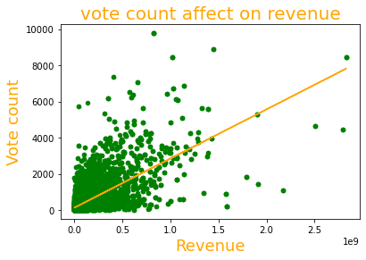

```python
vote_to_revenue(df)
plt.title('vote count affect on revenue', fontsize = 20, color = 'orange')
plt.xlabel('Revenue', fontsize=18, color = 'orange')
plt.ylabel('Vote count', fontsize = 18, color = 'orange')
plt.show();
```

Positive correlation betwwen Budget and revenue

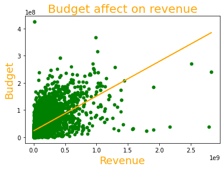

```python
budget_to_revenue(df)
plt.title('Budget affect on revenue', fontsize = 20, color = 'orange')
plt.xlabel('Revenue', fontsize=18, color = 'orange')
plt.ylabel('Budget', fontsize = 18, color = 'orange')
plt.show();
```

bar chart shows that relation between movie genres and top 25% movie revenues

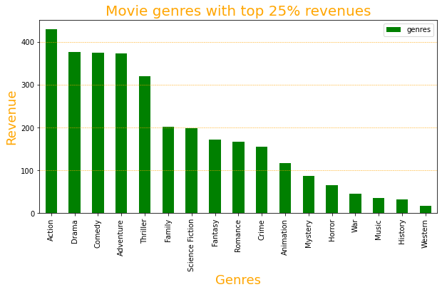

```python
top_genres_count(df)
plt.title('Movie genres with top 25% revenues', fontsize = 20, color = 'orange')
plt.xlabel('Genres', fontsize=18, color = 'orange')
plt.ylabel('Revenue', fontsize = 18, color = 'orange')
plt.grid(axis = 'y',color = 'orange', linestyle = '--', linewidth = 0.5)
plt.legend();
```

repetation of directors for highest revenue movies shows that the director effect on revenue

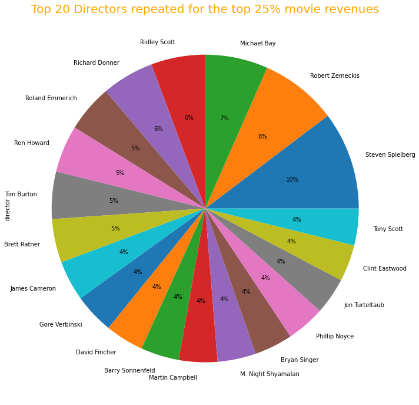

```python
top_directors(df).head(20).plot(kind = 'pie',figsize = (12,12),autopct='%1.0f%%')
plt.title('Top 20 Directors repeated for the top 25% movie revenues', fontsize = 20, color = 'orange');
```